# ATELIER 3 : EAU

Auteur·rice

SANGARE Nouhoun, NZI Parfait, YAO Affouet Prisca Elodie

Date de publication

2025-05-27

> Exemple de traitement réalisé par les groupes d’auditeur à partir de l’enquête AfroMapR.

# 1. Préparation des données

## Choix des variables à analyser

On sélectionne dans le tableau une variable Y que l’on veut expliquer et une variables X qui peut servir à expliquer Y. On décide par exemple d’examiner les variables suivantes :

- **Y : eau_robinet** : Consomme de l’eau du robinet
- **X : instr** : Niveau d’instruction

## Recodage éventuel des étiquettes

On peut raccourcir ou modifier les étiquettes pour faciliter leur affichage ou fusionner des modalités trop peu nombreuses. Ici on a regroupé les diplômés du supérieur, trop peu nombreux, avec ceux du secondaire.

# 2. Analyse de la variable à expliquer Y

## Fréquence simple

| Modalité | Fréquence |
| --- | --- |
| Non | 44 |
| Oui | 70 |
| Sum | 114 |

## Pourcentage

| Modalité | % |
| --- | --- |
| Non | 38.6 |
| Oui | 61.4 |
| Sum | 100.0 |

## Diagramme en bâtons

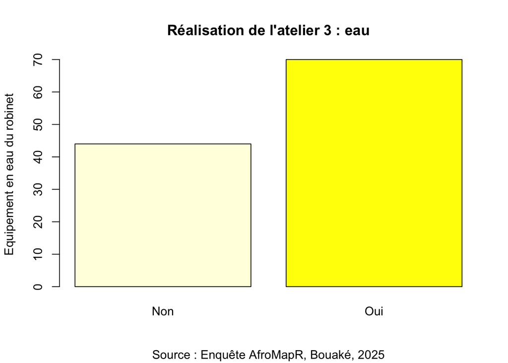

# 3. Analyse de la variable explicative X

## Fréquence simple

| Modalité | Fréquence |
| --- | --- |
| Aucun | 24 |
| Ecole coran. | 20 |
| Primaire | 31 |
| Secondaire et sup. | 39 |
| Sum | 114 |

## Pourcentage

| Modalité | % |
| --- | --- |
| Aucun | 21.1 |
| Ecole coran. | 17.5 |
| Primaire | 27.2 |
| Secondaire et sup. | 34.2 |
| Sum | 100.0 |

## Diagramme en bâtons

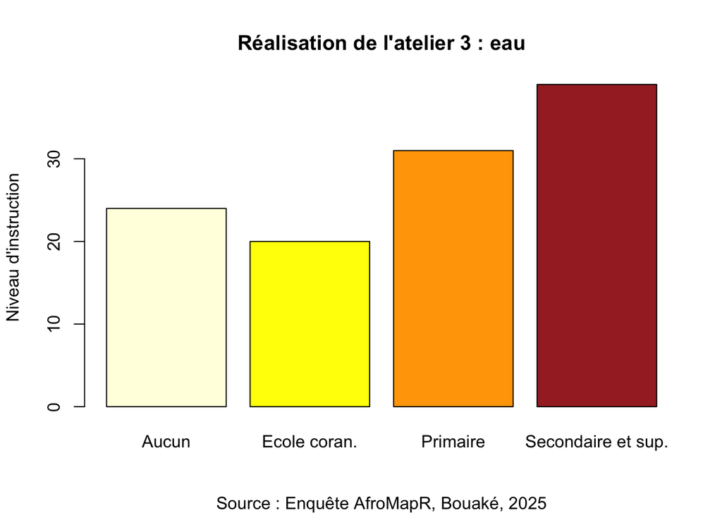

# 4. Relation entre X et Y

## Hypothèses

On veut tester l’existence d’une relation entre les deux variables précédentes.

- **H0** : Il n’y a pas de relation entre X et Y
- **H1** : Il y a une relation entre X et Y
- **Justification de l’hypothèse H1** : On suppose que les personnes disposant d’un diplôme élevé sont plus riches et plus sensibles aux enjeux de risque de maladie. Elles vivent également plus souvent en ville. Pour toutes ces raisons on suppose qu’elles seront mieux équipées en eau du robinet.

## Tableau de contingence

|  | Non | Oui | Sum |
| --- | --- | --- | --- |
| Aucun | 8 | 16 | 24 |
| Ecole coran. | 8 | 12 | 20 |
| Primaire | 14 | 17 | 31 |
| Secondaire et sup. | 14 | 25 | 39 |
| Sum | 44 | 70 | 114 |

## Pourcentage en ligne

|  | Non | Oui | Sum |
| --- | --- | --- | --- |
| Aucun | 33.3 | 66.7 | 100 |
| Ecole coran. | 40.0 | 60.0 | 100 |
| Primaire | 45.2 | 54.8 | 100 |
| Secondaire et sup. | 35.9 | 64.1 | 100 |
| Sum | 38.6 | 61.4 | 100 |

On constate des différences de poucentage en fonction du diplôme mais elles sont faibles et ne suivent pas l’hypothèse attendue. Les mieux équipés sont ainsi les personnes sans diplômes.

## Graphique en mosaïque

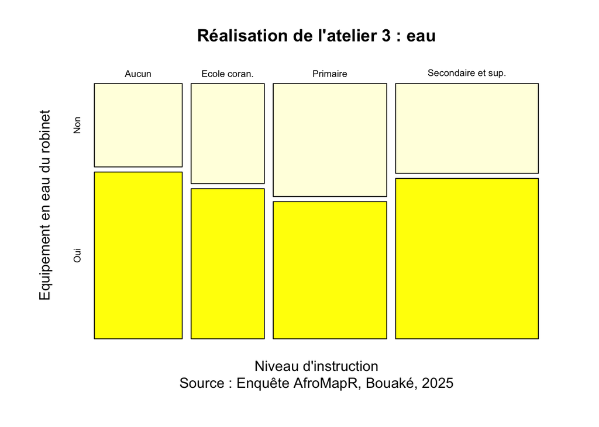

## Test du chi-2

On part de l’hypothèse nulle H0 : il n’y a pas de relation entre X et Y. Les variations en Y en fonction de X sont l’effet du hasard.

On effectue un test du chi-2 qui donne les résultats suivants :

```
    Pearson's Chi-squared test

data:  tabcont
X-squared = 0.98074, df = 3, p-value = 0.8059
```

## Conclusion

Il n’est pas possible de rejeter l’hypothèse H0 puisque la p-value indique que la relation entre les deux variable a 80.5% de chances d’être l’effet du hasard. La petite taille de l’échantillon peut expliquer l’absence de relation significative.

Mais on peut aussi penser que le niveau de diplôme n’est pas forcément une bonne aproximation du niveau de richesse des individus car il dépend de l’âge ou, plus précisément de la génération.